# Solutions to Exercise Set 2 Interactive: A $300 Billion Strategy

Philipp Hein (17J FBL)

The purpose of this exercise is to become familiar with:

1. Some time series analysis tools;
2. Correlation matrices and principal component analysis (PCA) (see [readings of sessions 3-4](http://inseaddataanalytics.github.io/INSEADAnalytics/Report_s23.html));
3. More data manipulation and reporting tools (including Google Charts).

As always, while doing this exercise we will also see how to generate replicable and customizable reports. For this purpose the exercise uses the R Markdown capabilities (see [Markdown Cheat Sheet](https://www.rstudio.com/wp-content/uploads/2015/02/rmarkdown-cheatsheet.pdf) or a [basic introduction to R Markdown](http://rmarkdown.rstudio.com/authoring_basics.html)). These capabilities allow us to create dynamic reports. For example today’s date is 2017-01-30 (you need to see the .Rmd to understand that this is *not* a static typed-in date but it changes every time you compile the .Rmd - if the date changed of course).

Before starting, make sure you have pulled the [exercise set 2 source code files](https://github.com/InseadDataAnalytics/INSEADAnalytics/tree/master/Exercises/Exerciseset2) on your github repository (if you pull the course github repository you also get the exercise set files automatically). Moreover, make sure you are in the directory of this exercise. Directory paths may be complicated, and sometimes a frustrating source of problems, so it is recommended that you use these R commands to find out your current working directory and, if needed, set it where you have the main files for the specific exercise/project (there are other ways, but for now just be aware of this path issue). For example, assuming we are now in the “Data Analytics R version/INSEADAnalytics” directory, we can do these:

```r
getwd()
setwd("Exercises/Exerciseset2/")
list.files()
```

**Note:** as always, you can use the `help` command in Rstudio to find out about any R function (e.g. type `help(list.files)` to learn what the R function `list.files` does).

Let’s now see the exercise.

**IMPORTANT:** You should answer all questions by simply adding your code/answers in this document through editing the file ExerciseSet2.Rmd and then clicking on the “Knit HTML” button in RStudio. Once done, please post your .Rmd and html files in your github repository.

### The Exercise: Introduction

For this exercise we will use the Futures’ daily returns to develop what is considered to be a *“classic” hedge fund trading strategy*, a **futures trend following strategy**. There is a lot written about this, so it is worth doing some online search about “futures trend following”, or “Managed Futures”, or “Commodity Trading Advisors (CTA)”. There is about **[$300 billion](http://www.barclayhedge.com/research/indices/cta/Money_Under_Management.html)** invested on this strategy today, and is considered to be one of the **oldest hedge fund strategies**. Some example links are:

- [A fascinating report on 2 centuries of trend following from the CFM hedge - a $6 billion fund](https://www.trendfollowing.com/whitepaper/Two_Centuries_Trend_Following.pdf)
- [Another fascinating report on 1 century of trend following investing from AQR - a $130 billion fund](https://www.aqr.com/library/aqr-publications/a-century-of-evidence-on-trend-following-investing)
- [Wikipedia on CTAs](https://en.wikipedia.org/wiki/Commodity_trading_advisor)
- Morningstar on CTAs
- [A report](http://perspectives.pictet.com/wp-content/uploads/2011/01/Trading-Strategies-Final.pdf)
- [Man AHL (a leading hedge fund on CTAs - among others) - an $80 billion fund](https://www.ahl.com/)

Of course there are also many starting points for developing such a strategy (for example [this R bloggers one](http://www.r-bloggers.com/system-from-trend-following-factors/) (also on [github](https://gist.github.com/timelyportfolio/2855303)), or the [turtle traders website](http://turtletrader.com/) which has many resources.

In this exercise we will develop our own strategy from scratch.

*Note (given today’s market conditions):* **Prices of commodities, like oil or gold, can be excellent indicators of the health of the economy and of various industries, as we will also see below**.

### Getting the Futures Data

There are many ways to get futures data. For example, one can use the [Quandl package,](https://www.quandl.com/browse) or the [turtle traders resources,](http://turtletrader.com/hpd/) or (for INSEAD only) get data from the [INSEAD library finance data resources](http://sites.insead.edu/library/E_resources/ER_subject.cfm#Stockmarket) website. One has to pay attention on how to create continuous time series from underlying contracts with varying deliveries (e.g. see [here](https://www.quantstart.com/articles/Continuous-Futures-Contracts-for-Backtesting-Purposes) ). Using a combination of the resources above, we will use data for a number of commodities.

### Data description

Let’s load the data and see what we have.

```r
library("FactoMineR")
library("psych")
library("timeDate")
library("googleVis")
library("quantmod")
source("helpersSet2.R")
load("data/FuturesTrendFollowingData.Rdata")
```

We have data from 2001-01-02 to 2015-09-24 of daily returns for the following 64 futures:

```r
show_data = data.frame(colnames(futures_data))
m1 <- gvisTable(show_data, options = list(showRowNumber = TRUE, width = 1920,
    height = min(400, 27 * (nrow(show_data) + 1)), allowHTML = TRUE, page = "disable"))
print(m1, "chart")
```

### Basic data analysis

First let’s see how each of these futures performs:

Select Futures Contract:

SP500 E-Mini

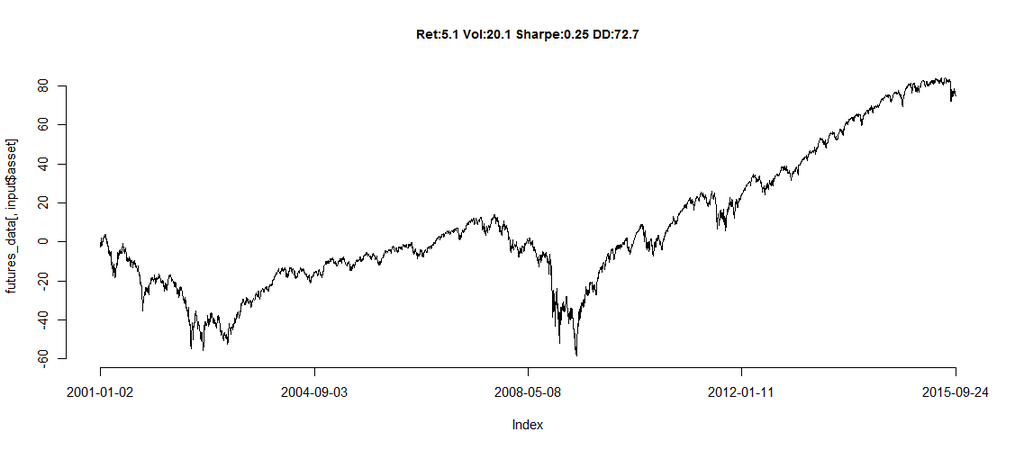

| Jan | Feb | Mar | Apr | May | Jun | Jul | Aug | Sep | Oct | Nov | Dec | Year |
| --- | --- | --- | --- | --- | --- | --- | --- | --- | --- | --- | --- | --- |
| 2.85 | -9.54 | -6.39 | 7.27 | 0.26 | -3.68 | -1.34 | -6.60 | -11.28 | 1.63 | 7.47 | 0.60 | -18.96 |
| -1.63 | -2.08 | 2.99 | -6.26 | -0.91 | -7.41 | -7.93 | 0.49 | -10.69 | 8.65 | 5.70 | -6.77 | -24.52 |
| -2.76 | -1.61 | -0.08 | 8.15 | 5.16 | 1.96 | 1.64 | 1.87 | -0.83 | 5.58 | 0.79 | 5.47 | 27.76 |
| 1.76 | 1.28 | -0.66 | -1.69 | 1.40 | 1.20 | -3.46 | 0.27 | 0.72 | 1.37 | 3.87 | 2.61 | 8.80 |
| -2.64 | 1.88 | -1.76 | -2.15 | 2.91 | 0.35 | 3.45 | -1.23 | 0.17 | -1.99 | 3.41 | 0.25 | 2.41 |
| 2.29 | -0.08 | 0.95 | 0.98 | -3.34 | -0.14 | 0.18 | 1.85 | 2.26 | 2.81 | 1.43 | 1.04 | 10.55 |
| 1.02 | -2.36 | 1.27 | 4.00 | 2.99 | -2.05 | -3.53 | 1.01 | 3.97 | 1.10 | -4.58 | -2.07 | 0.30 |
| -6.62 | -3.50 | -2.30 | 4.68 | 1.05 | -7.22 | -1.09 | 1.22 | -6.51 | -17.26 | -7.44 | 1.40 | -37.20 |
| -8.61 | -10.73 | 11.73 | 9.47 | 5.52 | 0.76 | 7.54 | 3.58 | 4.18 | -1.90 | 5.98 | 1.79 | 30.29 |
| -3.62 | 3.08 | 7.01 | 1.57 | -8.03 | -5.06 | 6.99 | -4.55 | 9.62 | 3.78 | -0.02 | 6.46 | 16.58 |
| 2.35 | 3.39 | 0.83 | 2.93 | -1.16 | -1.18 | -2.05 | -5.49 | -7.25 | 10.95 | -0.26 | 1.59 | 3.54 |
| 4.45 | 4.30 | 3.22 | -0.69 | -6.05 | 3.43 | 1.33 | 2.22 | 3.05 | -1.92 | 0.55 | 0.82 | 15.16 |
| 5.16 | 1.34 | 3.41 | 1.89 | 2.31 | -0.94 | 5.08 | -2.93 | 3.82 | 4.58 | 3.03 | 1.86 | 32.25 |
| -3.50 | 4.56 | 2.24 | 0.72 | 2.32 | 2.10 | -1.42 | 3.99 | -0.98 | 2.34 | 2.72 | -1.05 | 14.60 |
| -3.12 | 5.75 | -2.11 | 0.89 | 1.30 | -1.64 | 2.14 | -6.16 | -2.19 | NA | NA | NA | -5.49 |

Let’s also see how any equal-weighted (“1/n” where n is the total number of contracts - long plus short - selected) long/short portfolio would do for some selected futures contracts. Select the contracts you would like to be long and those to be short:

Select Futures Contract for Long:

Corn Wheat Soybeans Soybean Oil Soybean Meal Lean Hoggs Sugar Coffee Cocoa Cotton Canola Orange Juice Lumber Natural Gas Crude Oil Brent Crude Heating Oil Kerosene Gas Oil Gasoline Copper NY Copper LDN Silver Gold Platinum Palladium Aluminium Zinc Nickel Treasury Bonds 5 yr T-Notes US 2 yr T-Note US 10yr T-Notes Euro-Bund Euro-Bobl Euro-Schatz Canadian Bond JGB Japan Gilts UK Euroyen Eurodollar Euroswiss Euribor SP500 E-Mini DAX 30 Eurostoxx Hang Seng FTSE 100 UK Nasdaq 100 Mini Russel 2000 E-Mini Dow Jones TSE Toronto CAC 40 France OMX 30 Stockholm NIKKEI 225 Euro Norwegian Krone New Zealand Dollar Australian Dollar British Pound Canadian Dollar Swiss Franc Japanese Yen Singapore Dollar

Select Futures Contract for Short:

Corn Wheat Soybeans Soybean Oil Soybean Meal Lean Hoggs Sugar Coffee Cocoa Cotton Canola Orange Juice Lumber Natural Gas Crude Oil Brent Crude Heating Oil Kerosene Gas Oil Gasoline Copper NY Copper LDN Silver Gold Platinum Palladium Aluminium Zinc Nickel Treasury Bonds 5 yr T-Notes US 2 yr T-Note US 10yr T-Notes Euro-Bund Euro-Bobl Euro-Schatz Canadian Bond JGB Japan Gilts UK Euroyen Eurodollar Euroswiss Euribor SP500 E-Mini DAX 30 Eurostoxx Hang Seng FTSE 100 UK Nasdaq 100 Mini Russel 2000 E-Mini Dow Jones TSE Toronto CAC 40 France OMX 30 Stockholm NIKKEI 225 Euro Norwegian Krone New Zealand Dollar Australian Dollar British Pound Canadian Dollar Swiss Franc Japanese Yen Singapore Dollar

You can also scale your positions based on volatility, what is known as **[risk parity](http://www.investopedia.com/terms/r/risk-parity.asp)** - see also this [recent article.](http://www.econ.yale.edu/~af227/pdf/Leverage%20Aversion%20and%20Risk%20Parity%20-%20Asness%20,%20Frazzini%20and%20Pedersen.pdf)

Do you want to scale with volatility? (Note that doing this leads to some losses of days at the beginning of the series)

[figure not shown]

| Jan | Feb | Mar | Apr | May | Jun | Jul | Aug | Sep | Oct | Nov | Dec | Year |
| --- | --- | --- | --- | --- | --- | --- | --- | --- | --- | --- | --- | --- |
| 0.00 | 0.00 | 0.00 | 0.00 | 0.00 | 0.00 | 0.00 | 0.00 | 0.00 | 0.00 | 0.00 | 0.00 | 0.00 |
| 0.00 | 0.00 | 0.00 | 0.00 | 0.00 | 0.00 | 0.00 | 0.00 | 0.00 | 0.00 | 0.00 | 0.00 | 0.00 |
| 0.00 | 0.00 | 0.00 | 0.00 | 0.00 | 0.00 | 0.00 | 0.00 | 0.00 | 0.00 | 0.00 | 0.00 | 0.00 |
| 0.00 | 0.00 | 0.00 | 0.00 | 0.00 | 0.00 | 0.00 | 0.00 | 0.00 | 0.00 | 0.00 | 0.00 | 0.00 |
| 0.00 | 0.00 | 0.00 | 0.00 | 0.00 | 0.00 | 0.00 | 0.00 | 0.00 | 0.00 | 0.00 | 0.00 | 0.00 |
| 0.00 | 0.00 | 0.00 | 0.00 | 0.00 | 0.00 | 0.00 | 0.00 | 0.00 | 0.00 | 0.00 | 0.00 | 0.00 |
| 0.00 | 0.00 | 0.00 | 0.00 | 0.00 | 0.00 | 0.00 | 0.00 | 0.00 | 0.00 | 0.00 | 0.00 | 0.00 |
| 0.00 | 0.00 | 0.00 | 0.00 | 0.00 | 0.00 | 0.00 | 0.00 | 0.00 | 0.00 | 0.00 | 0.00 | 0.00 |
| 0.00 | 0.00 | 0.00 | 0.00 | 0.00 | 0.00 | 0.00 | 0.00 | 0.00 | 0.00 | 0.00 | 0.00 | 0.00 |
| 0.00 | 0.00 | 0.00 | 0.00 | 0.00 | 0.00 | 0.00 | 0.00 | 0.00 | 0.00 | 0.00 | 0.00 | 0.00 |
| 0.00 | 0.00 | 0.00 | 0.00 | 0.00 | 0.00 | 0.00 | 0.00 | 0.00 | 0.00 | 0.00 | 0.00 | 0.00 |
| 0.00 | 0.00 | 0.00 | 0.00 | 0.00 | 0.00 | 0.00 | 0.00 | 0.00 | 0.00 | 0.00 | 0.00 | 0.00 |
| 0.00 | 0.00 | 0.00 | 0.00 | 0.00 | 0.00 | 0.00 | 0.00 | 0.00 | 0.00 | 0.00 | 0.00 | 0.00 |
| 0.00 | 0.00 | 0.00 | 0.00 | 0.00 | 0.00 | 0.00 | 0.00 | 0.00 | 0.00 | 0.00 | 0.00 | 0.00 |
| 0.00 | 0.00 | 0.00 | 0.00 | 0.00 | 0.00 | 0.00 | 0.00 | 0.00 | NA | NA | NA | 0.00 |

as well as its 250-trading days rolling correlation of this strategy with the S&P:

[figure not shown]

Can you create a simple (“1/n”) long/short portfolio that performed well during this period? Why did that portfolio work in this period or during some part of the period? Do you expect it to also work in the future? Why and/or why not? How was its correlation with the S&P during this period?

Given such high correlations, we can try to see whether there are some “principal components” (see [reading on dimensionality reduction](http://inseaddataanalytics.github.io/INSEADAnalytics/Report_s23.html)). This analysis can also indicate whether all futures (the global economy!) are driven by some common “factors” (let’s call them *“risk factors”*).

```r
Variance_Explained_Table_results <- PCA(futures_data, graph = FALSE)
Variance_Explained_Table <- cbind(paste("component", 1:ncol(futures_data), sep = " "),
    Variance_Explained_Table_results$eig)
Variance_Explained_Table <- as.data.frame(Variance_Explained_Table)
colnames(Variance_Explained_Table) <- c("Component", "Eigenvalue", "Percentage_of_explained_variance",
    "Cumulative_percentage_of_explained_variance")
```

```r
eigenvalues <- Variance_Explained_Table[, 2]
```

```r
corused = cor(futures_data[, apply(futures_data != 0, 2, sum) > 10, drop = F])
Rotated_Results <- principal(corused, nfactors = min(20, ncol(corused)), rotate = "varimax",
    score = TRUE)
Rotated_Factors <- round(Rotated_Results$loadings, 2)
Rotated_Factors <- as.data.frame(unclass(Rotated_Factors))
colnames(Rotated_Factors) <- paste("Component", 1:ncol(Rotated_Factors), sep = " ")

sorted_rows <- sort(Rotated_Factors[, 1], decreasing = TRUE, index.return = TRUE)$ix
Rotated_Factors <- Rotated_Factors[sorted_rows, ]
Rotated_Factors_all = Rotated_Factors
Rotated_Factors[abs(Rotated_Factors) < 0.3] <- NA
```

#### Questions:

1. How many principal components (“factors”) do we need to explain at least 50% of the variance in this data?
2. What are the highest weights (in absolute value) of the first principal component portfolio above on the 64 futures?
3. Can we interpret the first 10 components? How would you call these factors?
4. Can you now generate the principal components and scree plot using only: a) the pre-crisis bull market years (e.g. only using the data between November 1, 2002, and October 1, 2007)? b) the financial crisis years (e.g. only using the data between October 1, 2007 and March 1, 2009), (Hint: you can select subsets of the data using for example the command `crisis_data = futures_data[as.Date(rownames(futures_data)) > “2007-10-01” & as.Date(rownames(futures_data)) < “2009-03-01”, ])
5. Based on your analysis in question 3, please discuss any differences you observe about the futures returns during bull and bear markets. What implications may these results have? What do the results imply about how assets are correlated during bear years compared to bull years?

**Your Answers here:**  
1. We need at least 6 factors in order to explain at least 50% of the variance.  
2. The three highest weights are:  
5 year T-Notes: 0.93  
10 year T-Notes: 0.93  
Treasury Bonds: 0.86  
3. The first ten components are:  
1. Government bonds  
2. Currency exchange  
3. European stock indices  
4. North American stock indices  
5. European foreign exchange futures  
6. Oil  
7. Metals (industrial)  
8. Agricultural commodities  
9. Precious metals  
10. East Asia stock indices  
4. For Pre-crisis Data:

```r
rotation_used="varimax"
MIN_VALUE=0.5
```

```r
factors_selected = 8

crisis_data = futures_data[as.Date(rownames(futures_data)) > "2002-11-01" & as.Date(rownames(futures_data)) < "2007-10-01", ]


Variance_Explained_Table_crisis_data_results<-PCA(crisis_data, graph=FALSE)
Variance_Explained_Table_crisis_data<-cbind(paste("component",1:ncol(crisis_data),sep=" "),Variance_Explained_Table_crisis_data_results$eig)
Variance_Explained_Table_crisis_data<-as.data.frame(Variance_Explained_Table_crisis_data)
colnames(Variance_Explained_Table_crisis_data)<-c("Component","Eigenvalue", "Percentage_of_explained_variance", "Cumulative_percentage_of_explained_variance")

show_data = data.frame(Variance_Explained_Table_crisis_data)
m1<-gvisTable(show_data,options=list(width=1920, height=min(400,27*(nrow(show_data)+1)),allowHTML=TRUE,page='disable'),formats=list(Eigenvalue="#.##",Percentage_of_explained_variance="#.##",Cumulative_percentage_of_explained_variance="#.##"))
print(m1,'chart')
```

```r
eigenvalues_crisis_data  <- Variance_Explained_Table_crisis_data[,2]

# scree plot
df           <- cbind(as.data.frame(eigenvalues_crisis_data), c(1:length(eigenvalues_crisis_data)), rep(1, length(eigenvalues_crisis_data)))
colnames(df) <- c("eigenvalues", "components", "abline")
Line         <- gvisLineChart(as.data.frame(df), xvar="components", yvar=c("eigenvalues","abline"), options=list(title='Scree plot', legend="right", width=900, height=600, hAxis="{title:'Number of Components', titleTextStyle:{color:'black'}}", vAxes="[{title:'Eigenvalues'}]",  series="[{color:'green',pointSize:3, targetAxisIndex: 0}]"))
print(Line, 'chart')
```

```r
# principal components
Rotated_Results<-principal(futures_data, nfactors=max(factors_selected), rotate=rotation_used,score=TRUE)
Rotated_Factors<-round(Rotated_Results$loadings,2)
Rotated_Factors<-as.data.frame(unclass(Rotated_Factors))
colnames(Rotated_Factors)<-paste("Component",1:ncol(Rotated_Factors),sep=" ")

sorted_rows <- sort(Rotated_Factors[,1], decreasing = TRUE, index.return = TRUE)$ix
Rotated_Factors <- Rotated_Factors[sorted_rows,]

show_data <- Rotated_Factors
show_data[abs(show_data) < MIN_VALUE] <-NA
show_data<-cbind(rownames(show_data),show_data)
colnames(show_data)<-c("Variables",colnames(Rotated_Factors))
m1<-gvisTable(show_data,options=list(showRowNumber=TRUE,width=1220, height=min(400,27*(nrow(show_data)+1)),allowHTML=TRUE,page='disable'))
print(m1,'chart')
```

Financial crisis years (2007-2009)

```r
factors_selected = 4

crisis_data = futures_data[as.Date(rownames(futures_data)) > "2007-10-01" & as.Date(rownames(futures_data)) < "2009-03-01", ]


Variance_Explained_Table_crisis_data_results<-PCA(crisis_data, graph=FALSE)
Variance_Explained_Table_crisis_data<-cbind(paste("component",1:ncol(crisis_data),sep=" "),Variance_Explained_Table_crisis_data_results$eig)
Variance_Explained_Table_crisis_data<-as.data.frame(Variance_Explained_Table_crisis_data)
colnames(Variance_Explained_Table_crisis_data)<-c("Component","Eigenvalue", "Percentage_of_explained_variance", "Cumulative_percentage_of_explained_variance")

show_data = data.frame(Variance_Explained_Table_crisis_data)
m1<-gvisTable(show_data,options=list(width=1920, height=min(400,27*(nrow(show_data)+1)),allowHTML=TRUE,page='disable'),formats=list(Eigenvalue="#.##",Percentage_of_explained_variance="#.##",Cumulative_percentage_of_explained_variance="#.##"))
print(m1,'chart')
```

```r
eigenvalues_crisis_data  <- Variance_Explained_Table_crisis_data[,2]

# scree plot
df           <- cbind(as.data.frame(eigenvalues_crisis_data), c(1:length(eigenvalues_crisis_data)), rep(1, length(eigenvalues_crisis_data)))
colnames(df) <- c("eigenvalues", "components", "abline")
Line         <- gvisLineChart(as.data.frame(df), xvar="components", yvar=c("eigenvalues","abline"), options=list(title='Scree plot', legend="right", width=900, height=600, hAxis="{title:'Number of Components', titleTextStyle:{color:'black'}}", vAxes="[{title:'Eigenvalues'}]",  series="[{color:'green',pointSize:3, targetAxisIndex: 0}]"))
print(Line, 'chart')
```

```r
# principal components
Rotated_Results<-principal(futures_data, nfactors=max(factors_selected), rotate=rotation_used,score=TRUE)
Rotated_Factors<-round(Rotated_Results$loadings,2)
Rotated_Factors<-as.data.frame(unclass(Rotated_Factors))
colnames(Rotated_Factors)<-paste("Component",1:ncol(Rotated_Factors),sep=" ")

sorted_rows <- sort(Rotated_Factors[,1], decreasing = TRUE, index.return = TRUE)$ix
Rotated_Factors <- Rotated_Factors[sorted_rows,]

show_data <- Rotated_Factors
show_data[abs(show_data) < MIN_VALUE] <-NA
show_data<-cbind(rownames(show_data),show_data)
colnames(show_data)<-c("Variables",colnames(Rotated_Factors))
m1<-gvisTable(show_data,options=list(showRowNumber=TRUE,width=1220, height=min(400,27*(nrow(show_data)+1)),allowHTML=TRUE,page='disable'))
print(m1,'chart')
```

### Interactive Analysis of Markets Over Time

We can also create an interactive tool to answer question 4 more generally. For example, one can select any time period and see how much of the variance of the 64 futures during that time period is explained using only the top N eigenvectors (**“risk factors”** driving the returns during that time period), how the top eigenvectors change, etc. Here is an example.

**Note**: once you select the sliders, you need to **wait a few seconds** until the figures “fades out” and then “fades in” again. You may also need to wait a few seconds the first time for the plots to render.

Starting Date:

End Date (allow at least 120 days from the starting day you selected - else it will automatically use data up to 120 days after your start date):

Factors used

5

This is the cumulative variance explained (whole period versus selected period) using tthe top selected eigenvectors (risk factors):

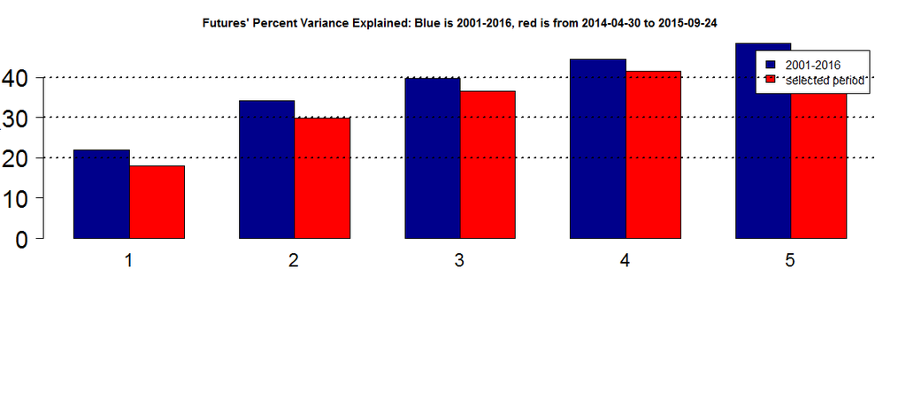

And here are the first 5 eigenvectors (**risk factors**) for the selected period, showing only the factor loadings that are larger than 0.3 in absolute value.

**Note**: we show the top (rotated) principal components for the **period selected**, and compare the loadings with those in the **fist (rotated) principal components of the entire period using the same order of components (e.g. 1 to 5)**. If for example in the selected period the first principal component mainly uses futures that are not highly used by the **first** principal component of the entire period (but may be used by the second one for the entire period, for example), we still show those futures from the first principal component of the entire period (in blue color).

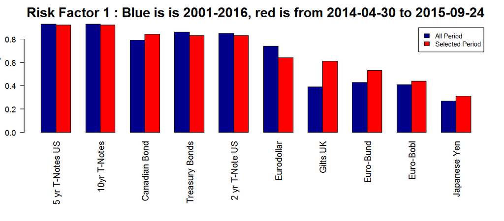

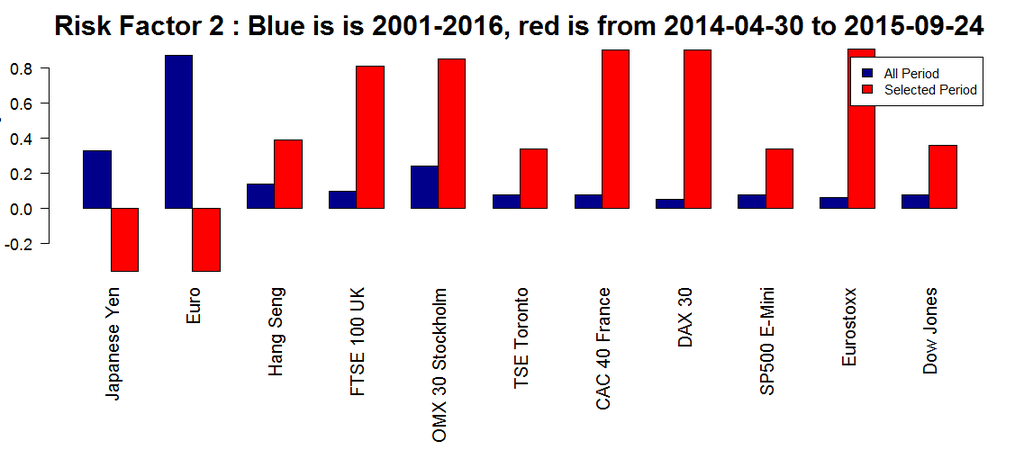

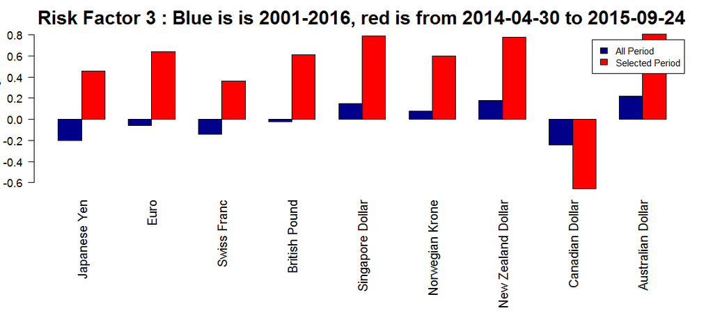

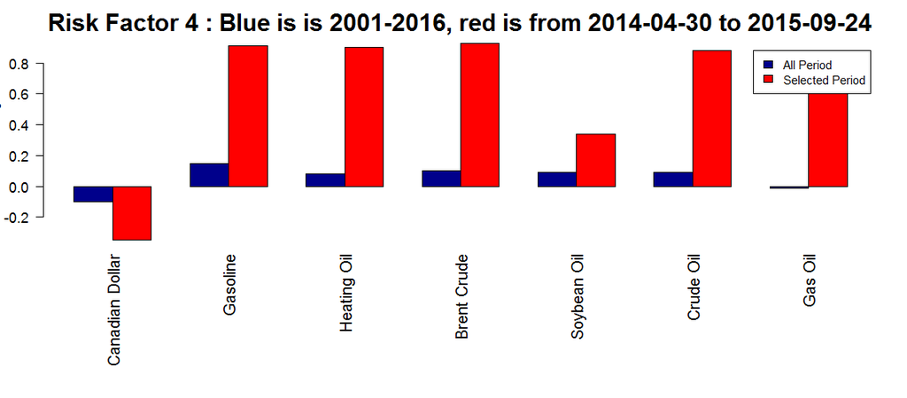

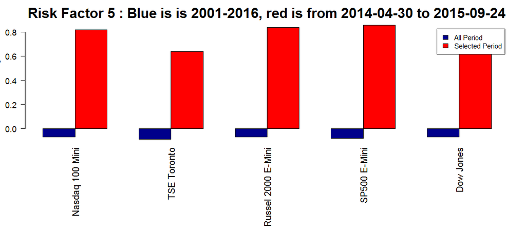

### A Simple Futures Trend Following Strategy

We can now develop a simple futures trend following trading strategy, as outlined in the papers in the Exercise Introduction above. There are about $300 billion invested in such strategies! Of course we cannot develop here a sophisticated product, but with some more work…

We will do the following:

1. Calculate a number of moving averages of different “window lengths” for each of the 64 futures - there are [many](http://www.r-bloggers.com/stock-analysis-using-r/) so called [technical indicators](http://www.investopedia.com/active-trading/technical-indicators/) one can use. We will use the “moving average” function `ma` for this (try for example to see what this returns `ma(1:10,2)` ).
2. Add the signs (can also use the actual moving average values of course - try it!) of these moving averages (as if they “vote”), and then scale this sum across all futures so that the sum of their (of the sum across all futures!) absolute value across all futures is 1 (hence we invest $1 every day - you see why?).
3. Then invest every day in each of the 64 an amount that is defined by the weights calculated in step 2, using however the weights calculated using data until 2 days ago (why 2 days and not 1 day?) - see the use of the helper function `shift` for this.
4. Finally see the performance of this strategy.

Here is the code.

```r
signal_used = 0 * futures_data  # just initialize the trading signal to be 0
# Take many moving Average (MA) Signals and let them 'vote' with their sign
# (+-1, e.g. long or short vote, for each signal)
MAfreq <- seq(10, 250, by = 20)
for (iter in 1:length(MAfreq)) signal_used = signal_used + sign(apply(futures_data,
    2, function(r) ma(r, MAfreq[iter])))
# Now make sure we invest $1 every day (so the sum of the absolute values of
# the weights is 1 every day)
signal_used = t(apply(signal_used, 1, function(r) {
    res = r
    if (sum(abs(r)) != 0)
        res = r/sum(abs(r))
    res
}))
colnames(signal_used) <- colnames(futures_data)
# Now create the returns of the strategy for each futures time series
strategy_by_future <- scrub(shift(signal_used, 2) * futures_data)  # use the signal from 2 days ago
# finally, this is our futures trend following strategy
trading_strategy = apply(strategy_by_future, 1, sum)
names(trading_strategy) <- rownames(futures_data)
```

### Reporting the performance results

Let’s see how this strategy does:

[figure not shown]

This is the 250-trading days rolling correlation of this simple strategy with the S&P:

[figure not shown]

How does this simple strategy compare with **existing CTA products** such as [this one from Societe Generale?](https://cib.societegenerale.com/fileadmin/indices_feeds/SG_CTA_Monthly_Report.pdf) (Note: one can easily achieve a correlation of more than 0.8 with this specific product - as well as with many other ones)

[figure not shown]

Compare our strategy with this product

#### Questions

1. Can you describe in more detail what the code above does?
2. What happens if you use different moving average technical indicators in the code above? Please explore and report below the returns of a trading strategy you build. (Hint: check that the command line `MAfreq<-seq(10,250,by=20)` above does for example - but not only of course, the possibilities are endless)

**Your Answers here:**  
1. The code above creates a list of moving averages. For every entry the program assess whether the return was positive or negative (indicated by a plus or minus).  
2. Since the moving averages change, we observe different financial results based on the period.

### A class competition

Now you have seen how to develop some trading strategies that hedge funds have been using for centuries. Clearly this is only the very first step - as many of the online resources on technical indicators also suggest. Can you now explore more such strategies? How good a **futures trend following hedge fund strategy** can you develop? Let’s call this…. a **class competition**! Explore as much as you can and report your best strategy as we move along the course…

Here is for example something that can be achieved relatively easily…

[figure not shown]

Or, interactively:

Starting Date:

End Date (allow at least 2 days from the starting day you selected - else it will automatically use data up to 2 days after your start date):

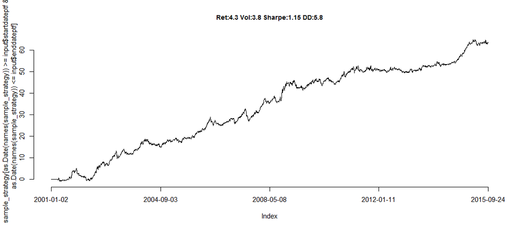

This is the 250-trading days rolling correlation of this strategy with the S&P:

[figure not shown]

Finally, deploy this shiny app using `shinyapps::deployApp('ExerciseSet2.Rmd')` (you need a [shinyapps.io](https://www.shinyapps.io/) account for this).

As always, **have fun**